1. Introduction

# Ford GoBike System Data Analysis

## Introduction

This notebook explores the Ford GoBike System Data to answer the following business questions:

1. What are the peak times and days for bike usage? Understanding peak usage times can help in optimizing bike distribution and station management.
2. How does bike usage vary by user type and gender? Analyzing bike usage across different user demographics can guide targeted marketing strategies and service improvements.
3. What are the most common start and end stations, and how does this impact the overall efficiency of the bike-sharing system? Identifying popular stations can help in optimizing bike placement and ensuring that high-demand areas are well-served.

The goal is to prepare the data, analyze it, and provide insights that address these questions.

2. Data Preparation

```python
# Step 1: Import Necessary Packages
import pandas as pd
import numpy as np
import matplotlib.pyplot as plt
import seaborn as sns
from sklearn.preprocessing import StandardScaler, LabelEncoder
from sklearn.cluster import KMeans
from sklearn.impute import SimpleImputer
import statsmodels.api as sm

# Step 2: Load Data
df = pd.read_csv("201902-fordgobike-tripdata.csv")

df.head()
```

|  | duration_sec | start_time | end_time | start_station_id | start_station_name | start_station_latitude | start_station_longitude | end_station_id | end_station_name | end_station_latitude | end_station_longitude | bike_id | user_type | member_birth_year | member_gender | bike_share_for_all_trip |
| --- | --- | --- | --- | --- | --- | --- | --- | --- | --- | --- | --- | --- | --- | --- | --- | --- |
| 0 | 52185 | 2019-02-28 17:32:10.1450 | 2019-03-01 08:01:55.9750 | 21.0 | Montgomery St BART Station (Market St at 2nd St) | 37.789625 | -122.400811 | 13.0 | Commercial St at Montgomery St | 37.794231 | -122.402923 | 4902 | Customer | 1984.0 | Male | No |
| 1 | 42521 | 2019-02-28 18:53:21.7890 | 2019-03-01 06:42:03.0560 | 23.0 | The Embarcadero at Steuart St | 37.791464 | -122.391034 | 81.0 | Berry St at 4th St | 37.775880 | -122.393170 | 2535 | Customer | NaN | NaN | No |
| 2 | 61854 | 2019-02-28 12:13:13.2180 | 2019-03-01 05:24:08.1460 | 86.0 | Market St at Dolores St | 37.769305 | -122.426826 | 3.0 | Powell St BART Station (Market St at 4th St) | 37.786375 | -122.404904 | 5905 | Customer | 1972.0 | Male | No |
| 3 | 36490 | 2019-02-28 17:54:26.0100 | 2019-03-01 04:02:36.8420 | 375.0 | Grove St at Masonic Ave | 37.774836 | -122.446546 | 70.0 | Central Ave at Fell St | 37.773311 | -122.444293 | 6638 | Subscriber | 1989.0 | Other | No |
| 4 | 1585 | 2019-02-28 23:54:18.5490 | 2019-03-01 00:20:44.0740 | 7.0 | Frank H Ogawa Plaza | 37.804562 | -122.271738 | 222.0 | 10th Ave at E 15th St | 37.792714 | -122.248780 | 4898 | Subscriber | 1974.0 | Male | Yes |

3. Analysis, Modeling, and Visualization

Peak Times and Days

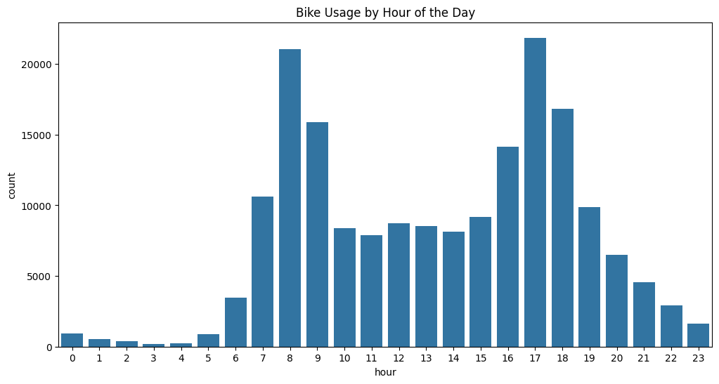

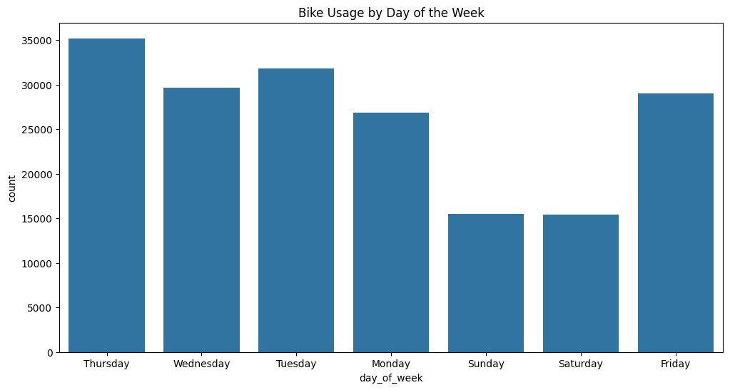

```python
# Convert start_time to datetime
df['start_time'] = pd.to_datetime(df['start_time'])
df['hour'] = df['start_time'].dt.hour
df['day_of_week'] = df['start_time'].dt.day_name()

# Plot usage by hour
plt.figure(figsize=(12, 6))
sns.countplot(data=df, x='hour')
plt.title('Bike Usage by Hour of the Day')
plt.show()

# Plot usage by day of week
plt.figure(figsize=(12, 6))
sns.countplot(data=df, x='day_of_week')
plt.title('Bike Usage by Day of the Week')
plt.show()
```

Bike Usage by User Type and Gender

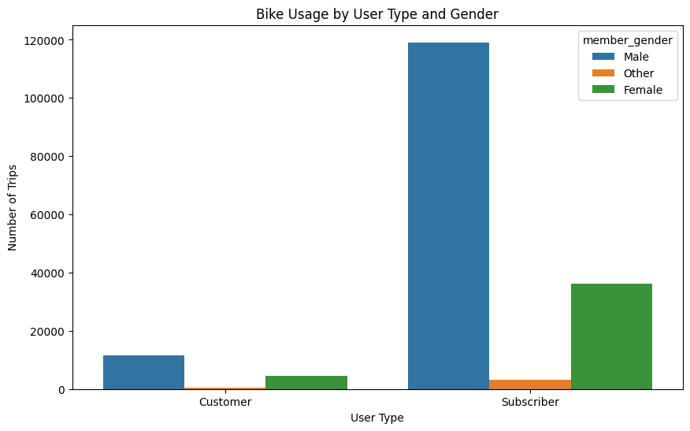

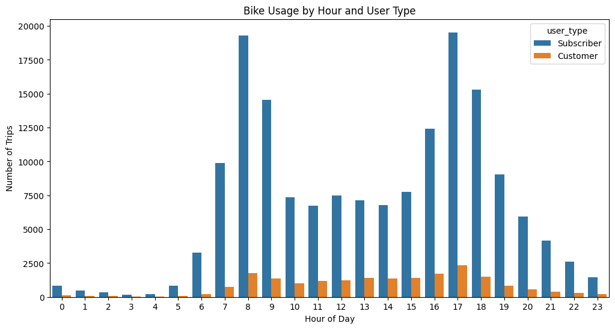

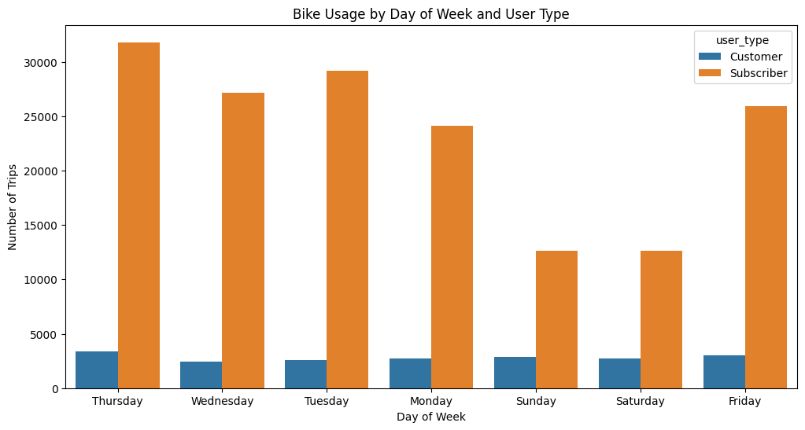

```python
# Convert start_time to datetime
df['start_time'] = pd.to_datetime(df['start_time'])

# Create hour and day of week columns
df['hour'] = df['start_time'].dt.hour
df['day_of_week'] = df['start_time'].dt.day_name()

# Bike usage by user type
plt.figure(figsize=(10, 6))
sns.countplot(data=df, x='user_type', hue='member_gender')
plt.title('Bike Usage by User Type and Gender')
plt.xlabel('User Type')
plt.ylabel('Number of Trips')
plt.show()

# Bike usage by hour and user type
plt.figure(figsize=(12, 6))
sns.countplot(data=df, x='hour', hue='user_type')
plt.title('Bike Usage by Hour and User Type')
plt.xlabel('Hour of Day')
plt.ylabel('Number of Trips')
plt.show()

# Bike usage by day of week and user type
plt.figure(figsize=(12, 6))
sns.countplot(data=df, x='day_of_week', hue='user_type')
plt.title('Bike Usage by Day of Week and User Type')
plt.xlabel('Day of Week')
plt.ylabel('Number of Trips')
plt.show()
```

Popular Stations

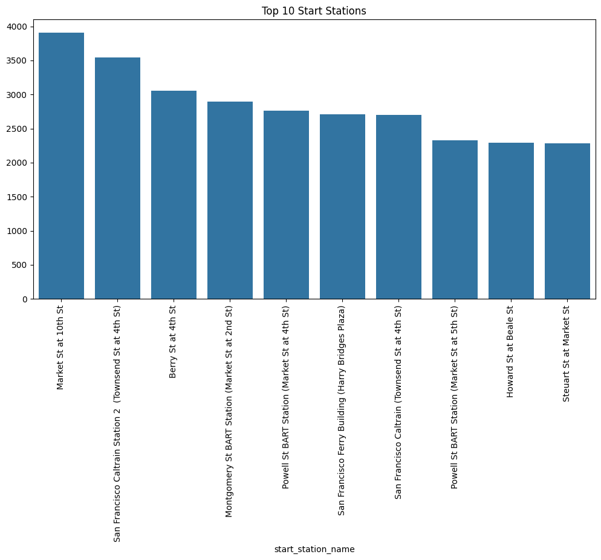

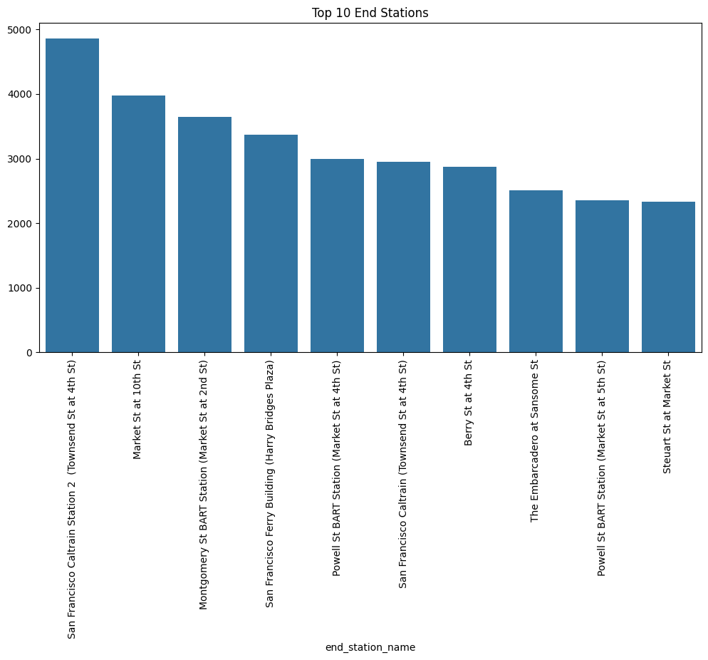

```python
# Find top 10 start stations
top_start_stations = df['start_station_name'].value_counts().head(10)
plt.figure(figsize=(12, 6))
sns.barplot(x=top_start_stations.index, y=top_start_stations.values)
plt.xticks(rotation=90)
plt.title('Top 10 Start Stations')
plt.show()

# Find top 10 end stations
top_end_stations = df['end_station_name'].value_counts().head(10)
plt.figure(figsize=(12, 6))
sns.barplot(x=top_end_stations.index, y=top_end_stations.values)
plt.xticks(rotation=90)
plt.title('Top 10 End Stations')
plt.show()
```

4. Conclusions